# The_stroke.ipynb

# Introduction

- Stroke or sometimes known as brain attack happens when when blood supply does not reach to the brain due to blockage or the blood vessels in the brain bursts.
- A stroke can cause lasting brain damage, long-term disability, or even death because it is an important but complex organ as it controls most of our body functions. *There are two types of stroke. Ischemic stroke is where the blood vessels are block by blood clot or any particles and hemorrhagic stroke in which artery in the brain ruptured.
- According to the World Health Organization (WHO) stroke is the 2nd leading cause of death globally, responsible for approximately 11% of total deaths. Early detection of stroke using prediction model can allow medical officers to provide immediate or efficient treatment that may minimize the long-term effects of a stroke and even prevent death.
- A lot of factors contribute to the likelihood of someone getting a stroke such as age, gender, diseases that they have and smoking status.

#Initial Questions

1. Which factors are important in predicting stroke?
2. Which is the best sampling method for imbalanced data?
3. Which is the best classification model (logistic regression and random forest) for stroke prediction?

#Objective To predict the probability of stroke on individuals based on their age, gender, hypertension, heart disease, marital status, occupation, residence type, glucose level, BMI and smoking status.

# Data Preprocessing

We are getting the dataset downloaded from Kaggle - Stroke Prediction Dataset.

```r
## Import libraries and read dataset

library('dplyr')
df <-read.csv("https://github.com/jenifermjues/thestroke/raw/main/healthcare-dataset-stroke-data.csv")
head(df)
```

```
##      id gender age hypertension heart_disease ever_married     work_type
## 1  9046   Male  67            0             1          Yes       Private
## 2 51676 Female  61            0             0          Yes Self-employed
## 3 31112   Male  80            0             1          Yes       Private
## 4 60182 Female  49            0             0          Yes       Private
## 5  1665 Female  79            1             0          Yes Self-employed
## 6 56669   Male  81            0             0          Yes       Private
##   Residence_type avg_glucose_level  bmi  smoking_status stroke
## 1          Urban            228.69 36.6 formerly smoked      1
## 2          Rural            202.21  N/A    never smoked      1
## 3          Rural            105.92 32.5    never smoked      1
## 4          Urban            171.23 34.4          smokes      1
## 5          Rural            174.12   24    never smoked      1
## 6          Urban            186.21   29 formerly smoked      1
```

Removed ‘id’ field because it is not useful for this analysis.

```r
df <- subset( df, select = -id )
```

```r
## Summary of Data
#### View the structure of data
glimpse(df)
```

```
## Rows: 5,110
## Columns: 11
## $ gender            <chr> "Male", "Female", "Male", "Female", "Female", "Male"~
## $ age               <dbl> 67, 61, 80, 49, 79, 81, 74, 69, 59, 78, 81, 61, 54, ~
## $ hypertension      <int> 0, 0, 0, 0, 1, 0, 1, 0, 0, 0, 1, 0, 0, 0, 0, 1, 0, 1~
## $ heart_disease     <int> 1, 0, 1, 0, 0, 0, 1, 0, 0, 0, 0, 1, 0, 1, 1, 0, 1, 0~
## $ ever_married      <chr> "Yes", "Yes", "Yes", "Yes", "Yes", "Yes", "Yes", "No~
## $ work_type         <chr> "Private", "Self-employed", "Private", "Private", "S~
## $ Residence_type    <chr> "Urban", "Rural", "Rural", "Urban", "Rural", "Urban"~
## $ avg_glucose_level <dbl> 228.69, 202.21, 105.92, 171.23, 174.12, 186.21, 70.0~
## $ bmi               <chr> "36.6", "N/A", "32.5", "34.4", "24", "29", "27.4", "~
## $ smoking_status    <chr> "formerly smoked", "never smoked", "never smoked", "~
## $ stroke            <int> 1, 1, 1, 1, 1, 1, 1, 1, 1, 1, 1, 1, 1, 1, 1, 1, 1, 1~
```

- *Class of age column is in double class (dbl) which indicates the age value is in decimal point*
- *Class of age column is in double class (dbl) which indicates the age value is in decimal point*

```r
#### View column names
names(df)
```

```
##  [1] "gender"            "age"               "hypertension"
##  [4] "heart_disease"     "ever_married"      "work_type"
##  [7] "Residence_type"    "avg_glucose_level" "bmi"
## [10] "smoking_status"    "stroke"
```

Convert ‘age’ field into ‘age groups’ to smoothen the data and improves accuracy.

```r
df["age"] = cut(df$age, c(0, 10, 20, 30, 40, 50, 60,  70, 80, Inf), c("0-9", "10-19", "20-29", "30-39", "40-49", "50-59", "60-69", "70-79",  ">80"), include.lowest=TRUE)
```

Convert ‘avg_glucose_level’ into 3 levels (“Low”, “Normal”, “Diabetes”).

```r
df["avg_glucose_level"] = cut(df$avg_glucose_level, c(0, 80, 150, Inf), c("Low", "Normal",  "Diabetes"), include.lowest=TRUE)
```

```r
#check how many missing values in bmi
sum(df$bmi =="N/A")
```

```
## [1] 201
```

```r
#remove the row with missing bmi
df$bmi<-replace(df$bmi, df$bmi =="N/A" , NA)
df<-na.omit(df)
```

```r
# Mutating column name "BMI" and then changing data type to factor
df$bmi<-as.numeric(df$bmi)
df["bmi"] = cut(df$bmi, c(0, 18.5, 25, 30, 40 ,Inf), c("Underweight", "Healthy",  "Overweight", "Obese", "Very Obese"), include.lowest=TRUE)
```

```r
##### Calculating total number of missing value
sum(is.na(df))
```

```
## [1] 0
```

## EDA

Exploratory Data Analysis or EDA is being used for us to analyse the data at high level. With the help of EDA, we can understand and summarize the contents of data, identify any missing values, determine the quality of data and able to compare and contrast between one value and another.

```r
#Using RColorBrewer library to manage colours in R
library(RColorBrewer)
```

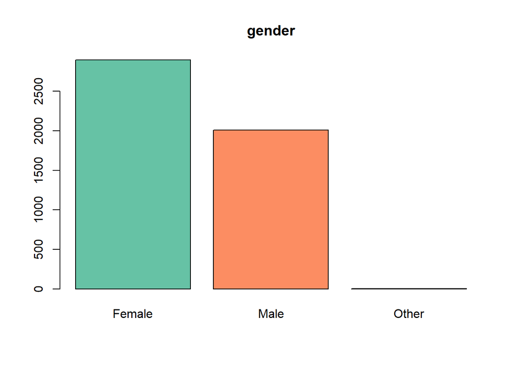

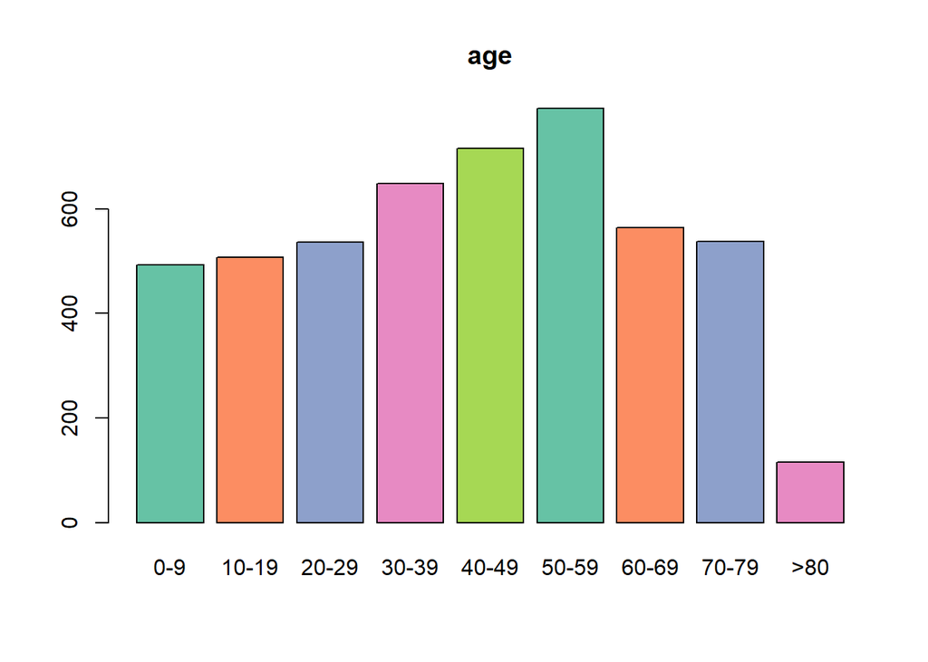

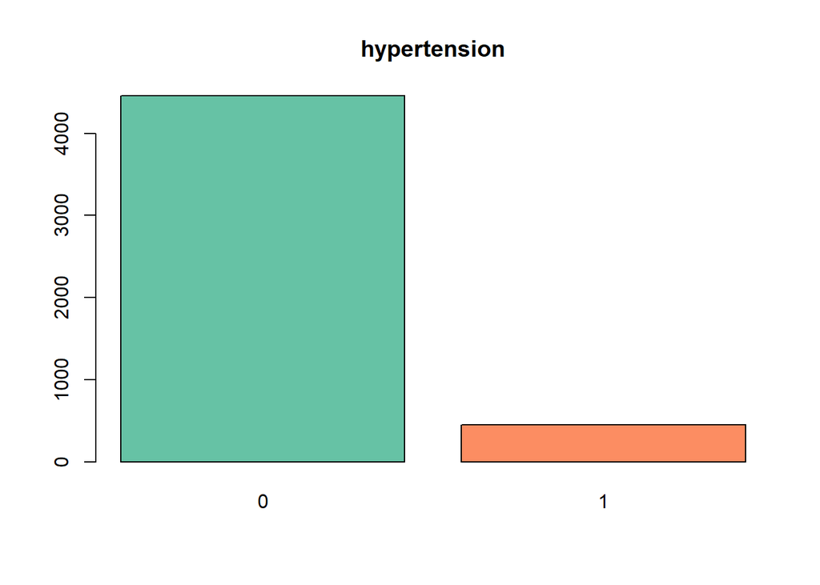

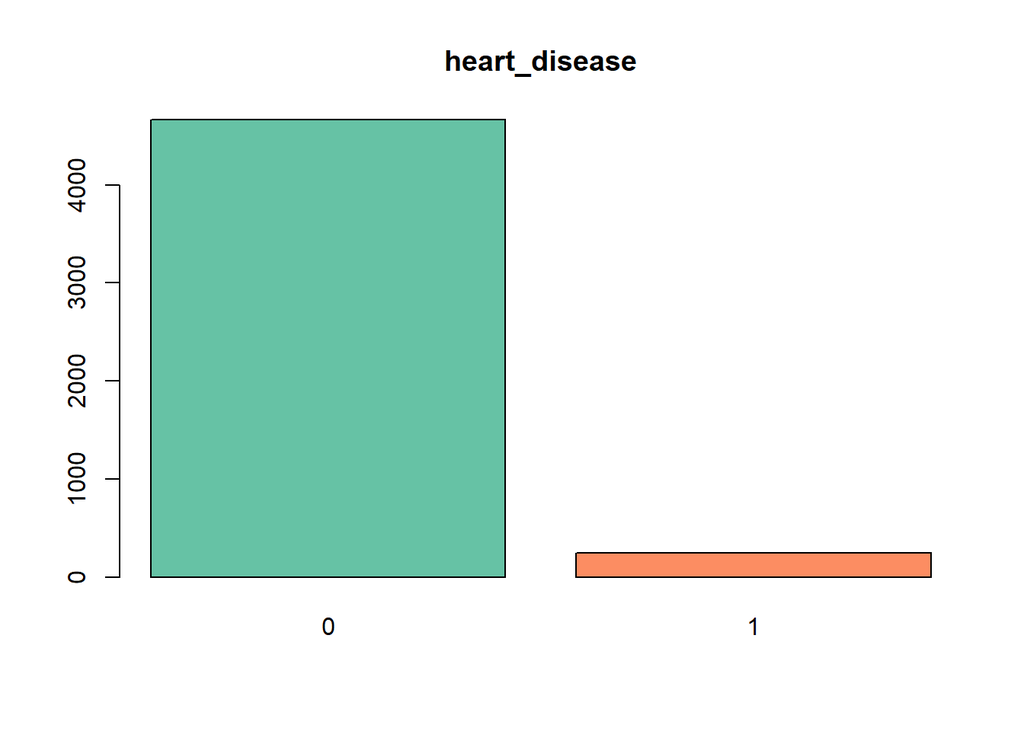

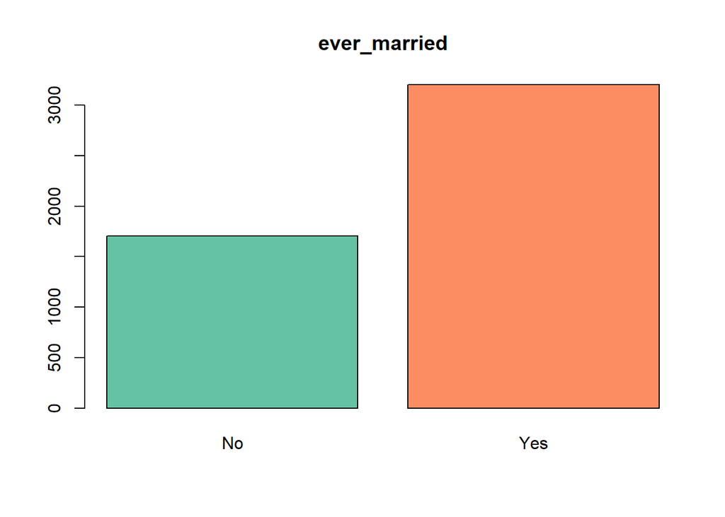

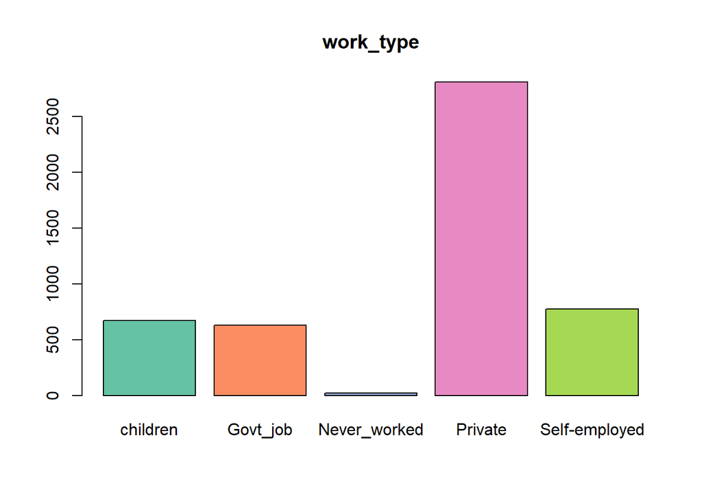

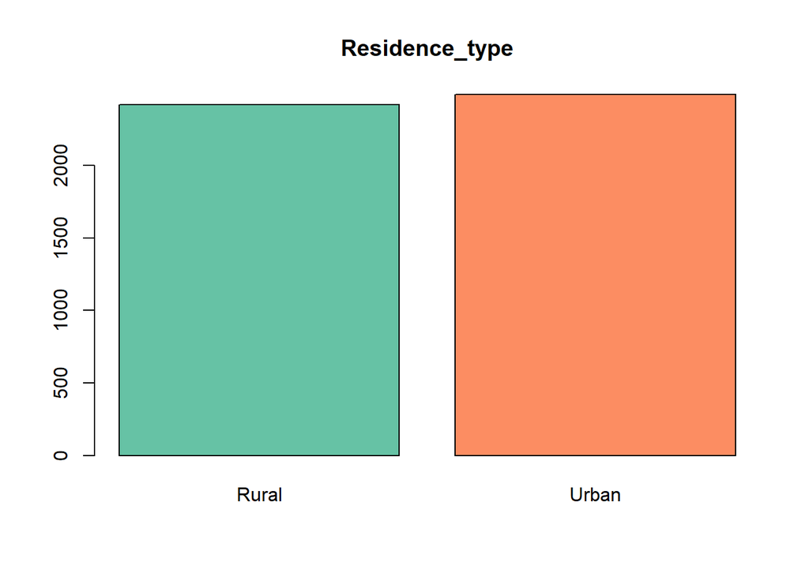

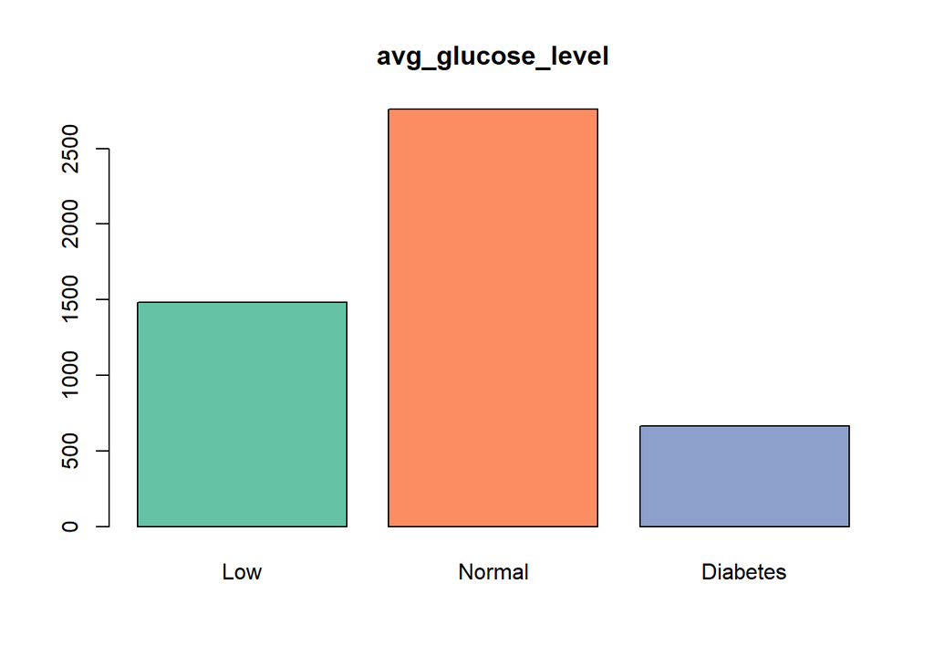

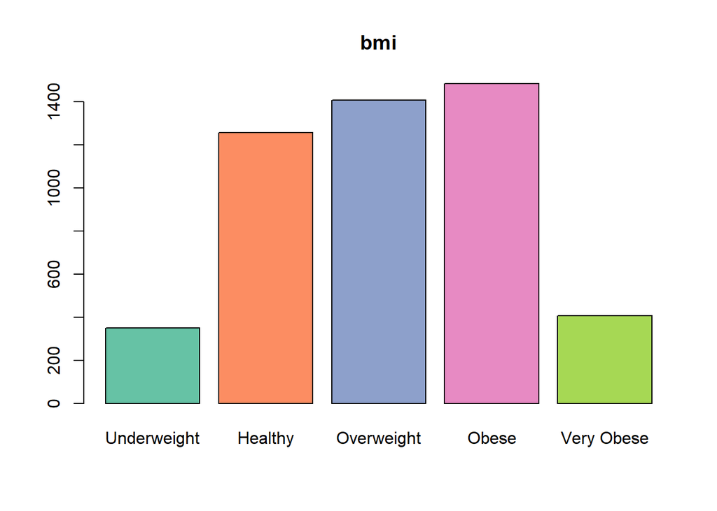

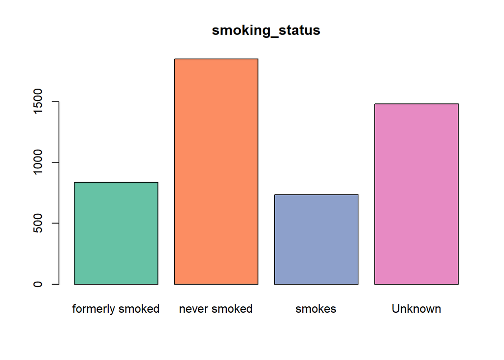

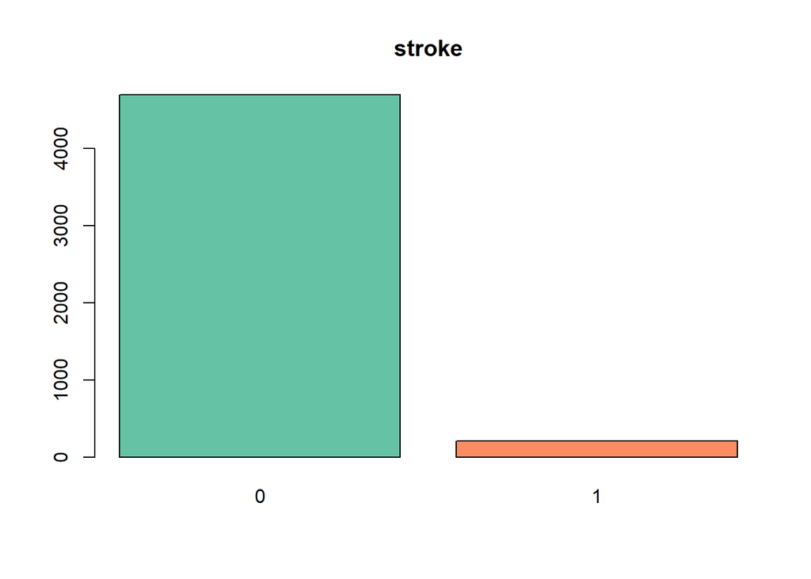

```r
#Plotting bar for each column
for (i in names(df)){
  barplot(table(df[i]), main = i, col = coul <- brewer.pal(5, "Set2") )
}
```

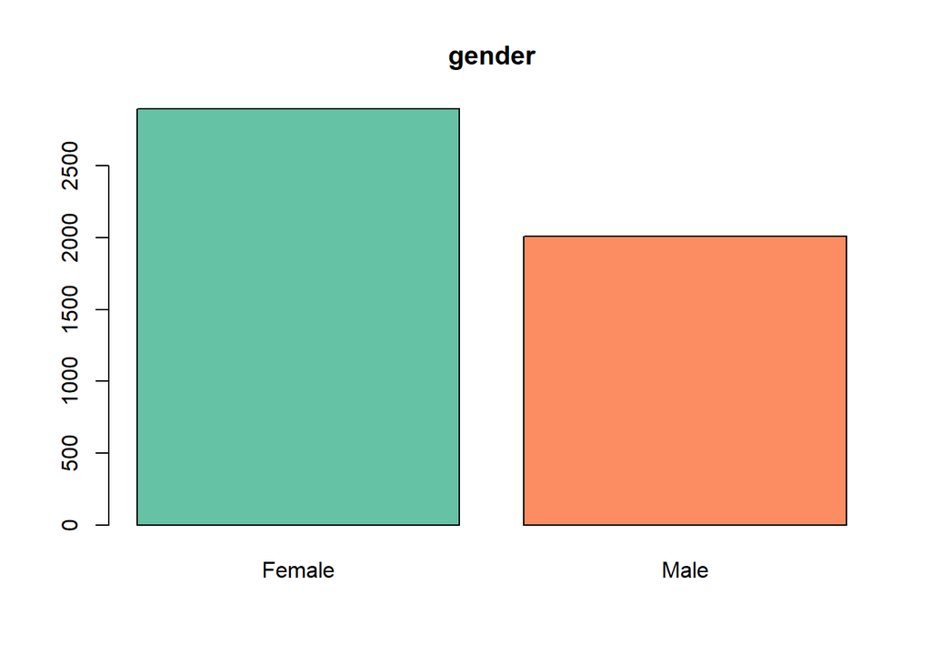

```r
#Showing values of gender, excluding "Other"
df<- df[df$gender!="Other",]
barplot(table(df["gender"]), main = "gender", col= brewer.pal(5, "Set2"))
```

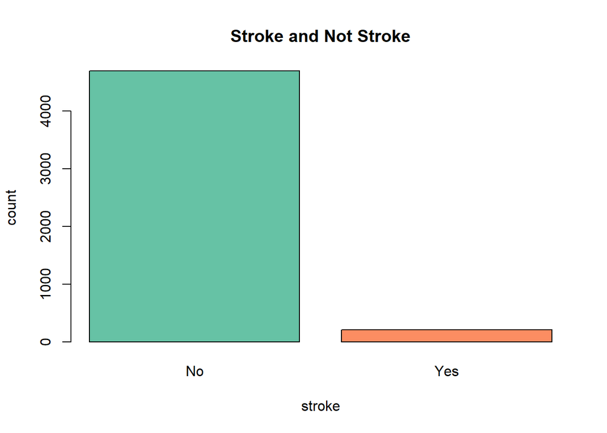

```r
#Changing value of stroke from 1 and 0 to "Yes" and "No"
temp_df<-df
temp_df$stroke[temp_df$stroke == 1] <- "Yes"
temp_df$stroke[temp_df$stroke == 0] <- "No"

#Plotting stroke values
count <- table(temp_df$stroke)
barplot(count,
        main="Stroke and Not Stroke",
        xlab="stroke",
        ylab="count",
        col= brewer.pal(5, "Set2"))
```

```r
library(reshape2)
library(dplyr)
library(ggplot2)
```

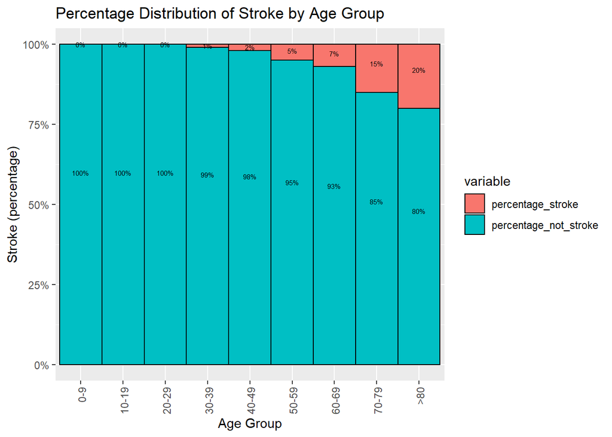

```r
# Plotting percentage distribution of stroke by age group
temp <-subset.data.frame(df, select = c(age, stroke)) %>%
  group_by(age, stroke) %>%
  summarize(n = n(), .groups = 'drop') %>%
  group_by(age) %>%
  summarize(percentage_stroke = round(sum(n[stroke==1]/sum(n)), digits=2),
            percentage_not_stroke = 1-percentage_stroke, .groups = 'drop') %>%
  arrange(desc(percentage_stroke)) %>%
  slice(1:9)
melted_temp<-melt(temp, id = "age")

ggplot(melted_temp, aes(x = age, y = value, fill = variable)) +
  geom_bar(position = "fill",
           stat = "identity",
           color = "black",
           width = 1) +
  theme(axis.text.x = element_text(angle = 90, hjust = 1, vjust = 0.6)) +
  scale_y_continuous(labels = scales::percent) +
  geom_text(aes(label = paste0(value*100,"%")),
            position = position_stack(vjust = 0.6), size = 2) +
  ggtitle("Percentage Distribution of Stroke by Age Group") +
  xlab("Age Group") +
  ylab("Stroke (percentage)")
```

```r
#Show transposed data
glimpse(df)
```

```
## Rows: 4,908
## Columns: 11
## $ gender            <chr> "Male", "Male", "Female", "Female", "Male", "Male", ~
## $ age               <fct> 60-69, 70-79, 40-49, 70-79, >80, 70-79, 60-69, 70-79~
## $ hypertension      <int> 0, 0, 0, 1, 0, 1, 0, 0, 1, 0, 0, 0, 1, 0, 1, 0, 0, 1~
## $ heart_disease     <int> 1, 1, 0, 0, 0, 1, 0, 0, 0, 1, 0, 1, 0, 1, 0, 0, 0, 0~
## $ ever_married      <chr> "Yes", "Yes", "Yes", "Yes", "Yes", "Yes", "No", "Yes~
## $ work_type         <chr> "Private", "Private", "Private", "Self-employed", "P~
## $ Residence_type    <chr> "Urban", "Rural", "Urban", "Rural", "Urban", "Rural"~
## $ avg_glucose_level <fct> Diabetes, Normal, Diabetes, Diabetes, Diabetes, Low,~
## $ bmi               <fct> Obese, Obese, Obese, Healthy, Overweight, Overweight~
## $ smoking_status    <chr> "formerly smoked", "never smoked", "smokes", "never ~
## $ stroke            <int> 1, 1, 1, 1, 1, 1, 1, 1, 1, 1, 1, 1, 1, 1, 1, 1, 1, 1~
```

```r
df$gender<-as.factor(df$gender)
df$hypertension <-as.factor(df$hypertension)
df$heart_disease<-as.factor(df$heart_disease)
df$ever_married <-as.factor(df$ever_married)
df$work_type<-as.factor(df$work_type)
df$Residence_type<-as.factor(df$Residence_type)
df$work_type<-as.factor(df$work_type)
df$smoking_status <-as.factor(df$smoking_status)
df$stroke<-as.factor(df$stroke)
```

```r
glimpse(df)
```

```
## Rows: 4,908
## Columns: 11
## $ gender            <fct> Male, Male, Female, Female, Male, Male, Female, Fema~
## $ age               <fct> 60-69, 70-79, 40-49, 70-79, >80, 70-79, 60-69, 70-79~
## $ hypertension      <fct> 0, 0, 0, 1, 0, 1, 0, 0, 1, 0, 0, 0, 1, 0, 1, 0, 0, 1~
## $ heart_disease     <fct> 1, 1, 0, 0, 0, 1, 0, 0, 0, 1, 0, 1, 0, 1, 0, 0, 0, 0~
## $ ever_married      <fct> Yes, Yes, Yes, Yes, Yes, Yes, No, Yes, Yes, Yes, Yes~
## $ work_type         <fct> Private, Private, Private, Self-employed, Private, P~
## $ Residence_type    <fct> Urban, Rural, Urban, Rural, Urban, Rural, Urban, Urb~
## $ avg_glucose_level <fct> Diabetes, Normal, Diabetes, Diabetes, Diabetes, Low,~
## $ bmi               <fct> Obese, Obese, Obese, Healthy, Overweight, Overweight~
## $ smoking_status    <fct> formerly smoked, never smoked, smokes, never smoked,~
## $ stroke            <fct> 1, 1, 1, 1, 1, 1, 1, 1, 1, 1, 1, 1, 1, 1, 1, 1, 1, 1~
```

```r
#Reformat values to numeric
df$gender <- ifelse(df$gender=="Male", 0, 1)
df$age<-as.numeric(df$age)
df$ever_married<- ifelse(df$ever_married=="Yes", 1, 0)
df$work_type<-as.numeric(as.factor(df$work_type))
df$Residence_type<-as.numeric(as.factor(df$Residence_type))
df$avg_glucose_level<-as.numeric(df$avg_glucose_level)
df$bmi<-as.numeric(df$bmi)
df$smoking_status<- as.numeric(as.factor(df$smoking_status))
```

```r
#Show transposed data
glimpse(df)
```

```
## Rows: 4,908
## Columns: 11
## $ gender            <dbl> 0, 0, 1, 1, 0, 0, 1, 1, 1, 1, 1, 1, 1, 0, 0, 1, 1, 1~
## $ age               <dbl> 7, 8, 5, 8, 9, 8, 7, 8, 9, 7, 6, 8, 5, 7, 8, 6, 8, 6~
## $ hypertension      <fct> 0, 0, 0, 1, 0, 1, 0, 0, 1, 0, 0, 0, 1, 0, 1, 0, 0, 1~
## $ heart_disease     <fct> 1, 1, 0, 0, 0, 1, 0, 0, 0, 1, 0, 1, 0, 1, 0, 0, 0, 0~
## $ ever_married      <dbl> 1, 1, 1, 1, 1, 1, 0, 1, 1, 1, 1, 1, 1, 1, 1, 0, 1, 1~
## $ work_type         <dbl> 4, 4, 4, 5, 4, 4, 4, 4, 4, 2, 4, 4, 5, 4, 4, 4, 2, 5~
## $ Residence_type    <dbl> 2, 1, 2, 1, 2, 1, 2, 2, 1, 1, 2, 2, 1, 2, 2, 2, 1, 2~
## $ avg_glucose_level <dbl> 3, 2, 3, 3, 3, 1, 2, 1, 2, 2, 2, 3, 3, 3, 3, 2, 3, 3~
## $ bmi               <dbl> 4, 4, 4, 2, 3, 3, 2, 2, 3, 4, 3, 3, 4, 4, 3, 4, 2, 5~
## $ smoking_status    <dbl> 1, 2, 3, 2, 1, 2, 2, 4, 2, 3, 3, 2, 2, 3, 3, 2, 3, 2~
## $ stroke            <fct> 1, 1, 1, 1, 1, 1, 1, 1, 1, 1, 1, 1, 1, 1, 1, 1, 1, 1~
```

## Feature Selection

We are using feature selection to remove any redundant and irrelvant data as it can help the machine learning algorithm to train faster and improve learning frequency.

```r
library(polycor)
```

```r
CorMat <- hetcor(df)
CorMat$correlations
```

```
##                         gender          age hypertension heart_disease
## gender             1.000000000  0.028893653 -0.038031769  -0.169951128
## age                0.028893653  1.000000000  0.525574364   0.643821795
## hypertension      -0.038031769  0.525574364  1.000000000   0.314390800
## heart_disease     -0.169951128  0.643821795  0.314390800   1.000000000
## ever_married       0.036380212  0.677220353  0.344848601   0.289100305
## work_type          0.072880560  0.524540347  0.261319929   0.238803572
## Residence_type     0.004351173  0.007894427 -0.001996983  -0.005107215
## avg_glucose_level -0.053429121  0.178258974  0.221168869   0.224012029
## bmi               -0.001236911  0.389904076  0.296939742   0.150695239
## smoking_status    -0.039258629 -0.383752831 -0.246110582  -0.154984255
## stroke            -0.015263398  0.590879827  0.377520311   0.393569428
##                   ever_married     work_type Residence_type avg_glucose_level
## gender             0.036380212  0.0728805601   0.0043511726      -0.053429121
## age                0.677220353  0.5245403472   0.0078944267       0.178258974
## hypertension       0.344848601  0.2613199291  -0.0019969829       0.221168869
## heart_disease      0.289100305  0.2388035724  -0.0051072150       0.224012029
## ever_married       1.000000000  0.4261147829   0.0047071911       0.126091140
## work_type          0.426114783  1.0000000000  -0.0008000039       0.063429850
## Residence_type     0.004707191 -0.0008000039   1.0000000000      -0.000950029
## avg_glucose_level  0.126091140  0.0634298496  -0.0009500290       1.000000000
## bmi                0.380966557  0.3794666432  -0.0013326057       0.135792848
## smoking_status    -0.311234686 -0.3443643610   0.0024195220      -0.084835198
## stroke             0.290622495  0.2167081674   0.0133493618       0.196123212
##                            bmi smoking_status      stroke
## gender            -0.001236911   -0.039258629 -0.01526340
## age                0.389904076   -0.383752831  0.59087983
## hypertension       0.296939742   -0.246110582  0.37752031
## heart_disease      0.150695239   -0.154984255  0.39356943
## ever_married       0.380966557   -0.311234686  0.29062250
## work_type          0.379466643   -0.344364361  0.21670817
## Residence_type    -0.001332606    0.002419522  0.01334936
## avg_glucose_level  0.135792848   -0.084835198  0.19612321
## bmi                1.000000000   -0.266616437  0.13237380
## smoking_status    -0.266616437    1.000000000 -0.17539206
## stroke             0.132373796   -0.175392056  1.00000000
```

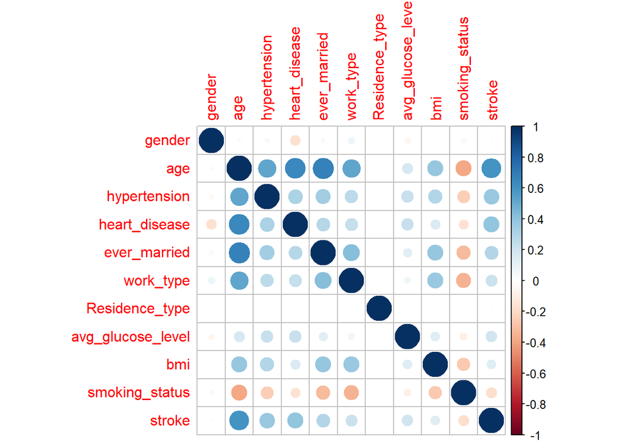

```r
#corrplot is used corrplot as it helps us to detect any hidden patterns among variables
library(corrplot)
#Plotting correlation matrix
corrplot(CorMat$correlations)
```

## Sampling Method

We use sampling method because we would like to identify the true association or the relationship between risk factors and stroke. In this project, random sampling is chosen.

```r
#Using caret (stands for Classification And REgression Training) package to create predictive model
library(caret)
#ROSE - Random Over Sampling to handle imbalance classes
library(ROSE)
#Create possibly balanced samples by random over-sampling using ovun.sample
balanced_sample<-NULL
tmp<-ovun.sample(stroke ~ ., data = df, method = "over", p = 0.5, seed = 5)$data
balanced_sample<-rbind(balanced_sample, tmp)
```

```r
#Create possibly balanced samples by random BOTH over- and under-sampling using ovun.sample
balanced_sample<-NULL
tmp<-ovun.sample(stroke ~ ., data = df, method = "both", p = 0.5, seed = 5)$data
balanced_sample<-rbind(balanced_sample, tmp)
```

```r
#Showing balanced sample
glimpse(balanced_sample)
```

```
## Rows: 4,908
## Columns: 11
## $ gender            <dbl> 1, 0, 0, 0, 1, 0, 0, 1, 1, 1, 0, 0, 1, 0, 0, 1, 1, 1~
## $ age               <dbl> 2, 6, 5, 8, 8, 6, 1, 2, 3, 2, 8, 8, 8, 5, 2, 4, 2, 8~
## $ hypertension      <fct> 0, 0, 0, 1, 0, 0, 0, 0, 0, 0, 0, 0, 0, 0, 0, 0, 0, 1~
## $ heart_disease     <fct> 0, 0, 0, 1, 0, 0, 0, 0, 0, 0, 1, 0, 0, 0, 0, 0, 0, 0~
## $ ever_married      <dbl> 0, 1, 1, 1, 1, 1, 0, 0, 0, 0, 1, 1, 1, 1, 0, 1, 0, 1~
## $ work_type         <dbl> 4, 5, 4, 5, 2, 2, 1, 3, 4, 4, 5, 4, 5, 4, 1, 4, 4, 5~
## $ Residence_type    <dbl> 2, 2, 1, 1, 1, 1, 1, 2, 1, 1, 1, 2, 1, 2, 1, 1, 1, 2~
## $ avg_glucose_level <dbl> 1, 1, 1, 3, 2, 2, 1, 1, 1, 2, 2, 3, 2, 1, 2, 2, 2, 1~
## $ bmi               <dbl> 2, 4, 4, 2, 3, 5, 2, 2, 4, 4, 4, 2, 2, 4, 2, 4, 4, 3~
## $ smoking_status    <dbl> 3, 3, 4, 2, 4, 3, 4, 2, 1, 4, 4, 2, 1, 3, 4, 2, 2, 1~
## $ stroke            <fct> 0, 0, 0, 0, 0, 0, 0, 0, 0, 0, 0, 0, 0, 0, 0, 0, 0, 0~
```

```r
summary(balanced_sample$stroke)
```

```
##    0    1
## 2441 2467
```

```r
#Set partition for train and test data
set.seed(123)
training.samples <- balanced_sample$stroke %>%
  createDataPartition(p = 0.8, list = FALSE)
train.data  <- balanced_sample[training.samples, ]
test.data <- balanced_sample[-training.samples, ]
```

# Data Training

Using the data to train or teach algorithm or machine learning model to predict the outcome. We have selected logistic regression as the model.

```r
# Logistics Regression
model  <- glm(stroke ~. , data = train.data, family = binomial)
summary(model)
```

```
##
## Call:
## glm(formula = stroke ~ ., family = binomial, data = train.data)
##
## Deviance Residuals:
##     Min       1Q   Median       3Q      Max
## -2.5513  -0.7433   0.2803   0.7776   2.5246
##
## Coefficients:
##                    Estimate Std. Error z value Pr(>|z|)
## (Intercept)       -5.250825   0.340258 -15.432  < 2e-16 ***
## gender             0.032572   0.082473   0.395  0.69289
## age                0.719304   0.029459  24.418  < 2e-16 ***
## hypertension1      0.741728   0.108310   6.848 7.48e-12 ***
## heart_disease1     0.425877   0.131191   3.246  0.00117 **
## ever_married       0.070620   0.127954   0.552  0.58101
## work_type         -0.075132   0.043742  -1.718  0.08587 .
## Residence_type     0.085650   0.080284   1.067  0.28605
## avg_glucose_level  0.185314   0.058269   3.180  0.00147 **
## bmi                0.116907   0.045963   2.544  0.01097 *
## smoking_status    -0.007137   0.039900  -0.179  0.85803
## ---
## Signif. codes:  0 '***' 0.001 '**' 0.01 '*' 0.05 '.' 0.1 ' ' 1
##
## (Dispersion parameter for binomial family taken to be 1)
##
##     Null deviance: 5443.9  on 3926  degrees of freedom
## Residual deviance: 3799.5  on 3916  degrees of freedom
## AIC: 3821.5
##
## Number of Fisher Scoring iterations: 5
```

# Data Prediction

```r
#Predicting probabilities
probabilities <- model %>% predict(test.data, type = "response")
head(probabilities)
```

```
##          3         15         21         22         28         42
## 0.23610178 0.03820600 0.04373472 0.14938668 0.66914804 0.59182104
```

# Evaluation

```r
summary(probabilities)
```

```
##    Min. 1st Qu.  Median    Mean 3rd Qu.    Max.
##  0.0141  0.2447  0.5692  0.5076  0.7691  0.9681
```

```r
predicted.classes <- ifelse(probabilities > 0.5, "1", "0")
```

```r
mean(predicted.classes == test.data$stroke)
```

```
## [1] 0.7502548
```

Random forest

```r
#Using randomForest for the evaluation
library(randomForest)
train.data$stroke<-as.character(train.data$stroke) #converting numeric train data to character
train.data$stroke<-as.factor(train.data$stroke) #converting numeric train data to factor
```

```r
classifier_RF = randomForest(x = train.data[-11],
                             y = train.data$stroke,
                             ntree = 500,
                             importance=TRUE)

classifier_RF
```

```
##
## Call:
##  randomForest(x = train.data[-11], y = train.data$stroke, ntree = 500,      importance = TRUE)
##                Type of random forest: classification
##                      Number of trees: 500
## No. of variables tried at each split: 3
##
##         OOB estimate of  error rate: 7.36%
## Confusion matrix:
##      0    1 class.error
## 0 1682  271 0.138760881
## 1   18 1956 0.009118541
```

```r
#Save the object to a file
saveRDS(classifier_RF, file="classifier_RF.rda")
```

```r
#Restore the object
classifier_RF<-readRDS("classifier_RF.rda")
```

```r
y_pred = predict(classifier_RF, newdata = df[1,-11])
```

```r
y_pred = predict(classifier_RF, newdata = test.data[-11])
# Confusion Matrix
confusion_mtx = table(test.data[, 11], y_pred)
confusionMatrix(confusion_mtx)
```

```
## Confusion Matrix and Statistics
##
##    y_pred
##       0   1
##   0 408  80
##   1   9 484
##
##                Accuracy : 0.9093
##                  95% CI : (0.8895, 0.9265)
##     No Information Rate : 0.5749
##     P-Value [Acc > NIR] : < 2.2e-16
##
##                   Kappa : 0.8184
##
##  Mcnemar's Test P-Value : 1.171e-13
##
##             Sensitivity : 0.9784
##             Specificity : 0.8582
##          Pos Pred Value : 0.8361
##          Neg Pred Value : 0.9817
##              Prevalence : 0.4251
##          Detection Rate : 0.4159
##    Detection Prevalence : 0.4975
##       Balanced Accuracy : 0.9183
##
##        'Positive' Class : 0
##
```

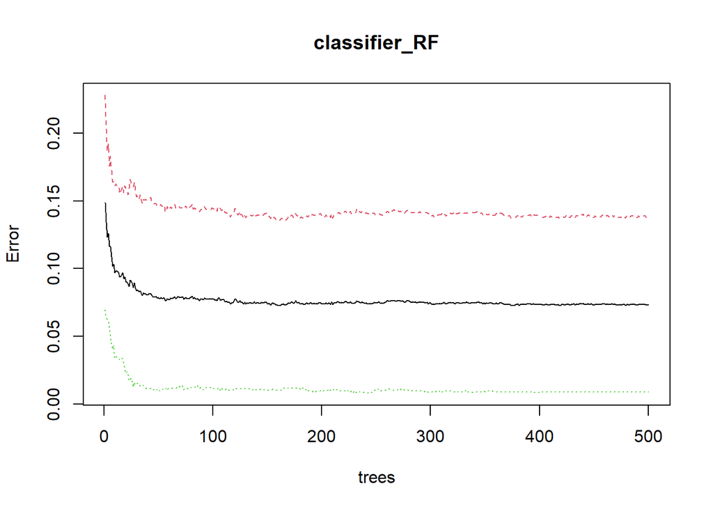

```r
# Plotting model
plot(classifier_RF)
```

```r
# Importance plot
importance(classifier_RF)
```

```
##                           0         1 MeanDecreaseAccuracy MeanDecreaseGini
## gender             7.806628  99.14289             96.81387         64.26269
## age               65.266616 152.77574            150.26509        589.69716
## hypertension      20.874362  87.78579             84.93729         71.32732
## heart_disease     18.382444  86.05248             81.75647         45.88701
## ever_married       7.080860  65.58945             65.84700         86.73023
## work_type         12.833062  99.77378            100.81712        133.12414
## Residence_type    15.470172  97.05152             93.28279         66.80121
## avg_glucose_level 16.447501 117.90573            113.36622        130.12802
## bmi               14.117372 113.13023            113.53414        143.01092
## smoking_status     9.806586 113.55881            108.45859        143.76381
```

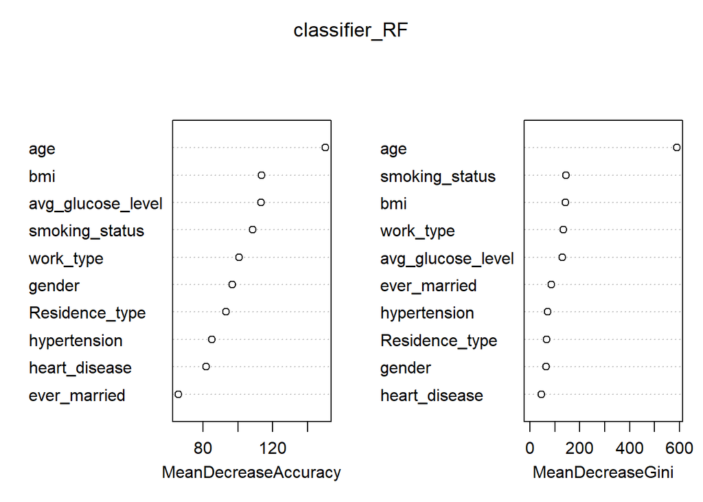

```r
# Variable importance plot
varImpPlot(classifier_RF)
```